# Organizational Network Analysis

Lakshmi

2025-07-05

# 🕸️ Intra-Organizational Network Analysis: A Case Study of a Consulting Firm

This project analyzes the internal advice-seeking network of 46 employees in a consulting company (Cross & Parker, 2004) to understand how information flows within the organization. The goal is to identify central individuals, bottlenecks, and structural patterns based on attributes such as role and gender.

I used two weighted, static, directed, one-mode networks:

### 1. **Information Frequency Network**

In the first network, the ties are differentiated on a scale from 0 to 5 in terms of frequency of information or advice requests

(“Please indicate how often you have turned to this person for information or advice on work-related topics in the past three months”).

```
- 0: Don't know this person
- 1: Never
- 2: Seldom
- 3: Sometimes
- 4: Often
- 5: Very Often
```

### 2. **Perceived Expertise Value Network**

In the second network, ties are differentiated in terms of the value placed on the information or advice received

(“For each person in the list below, please show how strongly you agree or disagree with the following statement: In general, this person has expertise in areas that are important in the kind of work I do.”).

```
- 0: Don't know this person
- 1: Strongly Disagree
- 2: Disagree
- 3: Neutral
- 4: Agree
- 5: Strongly Agree
```

Throughout this notebook, I used these networks to explore: - Centrality patterns (who is influential) - Attribute-based differences (e.g., by role or gender) - Structural efficiency and gaps - Business implications for improving collaboration

```r
# SETUP
#install.packages("sna")
#install.packages("intergraph")
#install.packages("netdiffuseR")
#install.packages("gplots")


## Loading in required packages
# --- Core network analysis & plotting ---
library(igraph) # For building and analyzing network graphs
library(ggraph) # For visualization of network graphs
# --- Data manipulation & Visualization ---
library(dplyr) # For data manipulation
library(readxl) # To import Excel files into R
library(ggplot2) # For general-purpose data visualization
library(gplots) # For enhanced plotting tools like heatmaps
library(patchwork) #For side-by-side graphs
# --- Advanced modeling & diffusion ---
library(sna) # Social network analysis: for further network analysis
library(intergraph) # To convert between igraph and statnet (network) objects
library(netdiffuseR) # For diffusion simulations and threshold models
```

## Data Loading

I’ve loaded three components of the dataset:

- `edges_info`: Edge list for the **information-seeking** network (frequency of advice).
- `edges_value`: Edge list for the **expertise-value** network (perceived value of advice).
- `nodes`: Node list containing employee attributes such as **role**, **gender**, and **location**.

```r
## Loading in Information seeking data
setwd("C:/Users/laksh/Desktop/projects/ONA/.")
edges_info <- readxl::read_excel("edge_list_info.xlsx")
names(edges_info)
```

```
## [1] "ego"    "alter"  "weight"
```

```r
## Loading in Value Perception edge data
edges_value <- readxl::read_excel("edge_list_value.xlsx")
names(edges_value)
```

```
## [1] "ego"    "alter"  "weight"
```

```r
## Loading in Node and node attribute data
nodes <- readxl::read_excel("node_list.xlsx")
names(nodes)
```

```
## [1] "ego"       "org_level" "gender"    "region"    "location"
```

```r
# Renaming 'value' to 'weight' for automatic igraph compatibility
colnames(edges_info)[colnames(edges_info) == "value"] = "weight"
colnames(edges_value)[colnames(edges_value) == "value"] ="weight"

summary(edges_info)
```

```
##       ego            alter           weight
##  Min.   : 1.00   Min.   : 1.00   Min.   :1.000
##  1st Qu.:12.00   1st Qu.:11.00   1st Qu.:1.000
##  Median :22.00   Median :22.00   Median :2.000
##  Mean   :22.62   Mean   :22.57   Mean   :2.241
##  3rd Qu.:33.00   3rd Qu.:34.00   3rd Qu.:3.000
##  Max.   :46.00   Max.   :46.00   Max.   :5.000
```

```r
summary(edges_value)
```

```
##       ego            alter           weight
##  Min.   : 1.00   Min.   : 1.00   Min.   :1.000
##  1st Qu.:13.00   1st Qu.:11.00   1st Qu.:3.000
##  Median :22.00   Median :23.00   Median :4.000
##  Mean   :23.34   Mean   :22.89   Mean   :3.819
##  3rd Qu.:34.00   3rd Qu.:34.00   3rd Qu.:5.000
##  Max.   :46.00   Max.   :46.00   Max.   :5.000
```

```r
summary(nodes)
```

```
##       ego          org_level         gender          region
##  Min.   : 1.00   Min.   :1.000   Min.   :1.000   Min.   :1.000
##  1st Qu.:12.25   1st Qu.:2.000   1st Qu.:1.000   1st Qu.:1.000
##  Median :23.50   Median :3.000   Median :1.000   Median :2.000
##  Mean   :23.50   Mean   :3.087   Mean   :1.239   Mean   :1.565
##  3rd Qu.:34.75   3rd Qu.:4.000   3rd Qu.:1.000   3rd Qu.:2.000
##  Max.   :46.00   Max.   :5.000   Max.   :2.000   Max.   :2.000
##     location
##  Min.   :1.000
##  1st Qu.:1.000
##  Median :1.000
##  Mean   :2.435
##  3rd Qu.:3.000
##  Max.   :7.000
```

### Node Attribute Metadata

The node list includes key employee attributes encoded numerically. Below is the mapping:

| Attribute | Code | Meaning |
| --- | --- | --- |
| **org_level** | 1 | Research Assistant |
|  | 2 | Junior Consultant |
|  | 3 | Senior Consultant |
|  | 4 | Managing Consultant |
|  | 5 | Partner |
| **gender** | 1 | Male |
|  | 2 | Female |
| **region** | 1 | Europe |
|  | 2 | USA |

The summary shows that the edge weights are on a 0–5 scale and the node data is cleanly structured for merging with the network.

This project mainly focuses on the organizational level and gender attributes for its analysis.

## Creating Network Objects

Below, I’ve created two `igraph` objects from the edge lists and node attributes:

- `net_info`: the information-seeking network, where edge weights represent **frequency** of advice (0–5 scale).
- `net_value`: the expertise-value network, where edge weights represent the **perceived value** of advice (0–5 scale).

Both networks are: - **Directed**: Edges have a direction (from source to target) - **Weighted**: Edges carry meaning based on the 0–5 rating scale - **One-mode**: All nodes are employees (no bipartite structure)

```r
## Creating Network Objects from Edge Lists

# Creating a directed, weighted network for the information-seeking (frequency) data
net_info <- graph_from_data_frame(edges_info, directed = TRUE, vertices = nodes)
net_info
```

```
## IGRAPH 61a731d DNW- 46 879 --
## + attr: name (v/c), org_level (v/n), gender (v/n), region (v/n),
## | location (v/n), weight (e/n)
## + edges from 61a731d (vertex names):
##  [1] 1->3  1->8  1->9  1->12 1->15 1->23 1->26 1->37 1->46 2->1  2->4  2->5
## [13] 2->6  2->7  2->8  2->10 2->11 2->12 2->13 2->14 2->16 2->18 2->19 2->20
## [25] 2->21 2->22 2->25 2->26 2->27 2->28 2->29 2->31 2->33 2->34 2->35 2->37
## [37] 2->38 2->41 3->1  3->4  3->8  3->9  3->12 3->22 3->31 3->32 3->33 3->37
## [49] 3->46 4->8  4->11 4->20 4->32 4->33 4->40 5->2  5->6  5->7  5->13 5->14
## [61] 5->17 5->18 5->19 5->20 5->21 5->23 5->25 5->26 5->27 5->28 5->29 5->34
## [73] 5->36 5->38 5->39 5->44 5->45 6->2  6->5  6->6  6->7  6->11 6->13 6->14
## + ... omitted several edges
```

```r
# Creating a directed, weighted network for the perceived value (expertise) data
net_value <- graph_from_data_frame(edges_value, directed = TRUE, vertices = nodes)
net_value
```

```
## IGRAPH 61aa575 DNW- 46 858 --
## + attr: name (v/c), org_level (v/n), gender (v/n), region (v/n),
## | location (v/n), weight (e/n)
## + edges from 61aa575 (vertex names):
##  [1] 1->3  1->8  1->9  1->12 1->15 1->23 1->26 1->31 1->32 1->37 1->46 2->1
## [13] 2->5  2->6  2->7  2->8  2->11 2->13 2->14 2->16 2->18 2->19 2->20 2->22
## [25] 2->25 2->26 2->27 2->28 2->29 2->31 2->33 2->34 2->35 2->37 2->38 2->41
## [37] 2->43 2->45 3->1  3->4  3->8  3->9  3->12 3->22 3->31 3->32 3->33 3->37
## [49] 3->46 4->8  4->31 4->32 4->33 4->40 5->2  5->6  5->13 5->14 5->17 5->19
## [61] 5->20 5->21 5->23 5->25 5->26 5->27 5->28 5->29 5->34 5->36 5->38 5->39
## [73] 5->44 5->45 6->2  6->5  6->6  6->7  6->11 6->13 6->14 6->17 6->19 6->20
## + ... omitted several edges
```

```r
#does the network have loops or multiplex ties?
is_simple(net_info)
```

```
## [1] FALSE
```

```r
is_simple(net_value)
```

```
## [1] FALSE
```

```r
#does the network have directed ties?
is_directed(net_info)
```

```
## [1] TRUE
```

```r
is_directed(net_value)
```

```
## [1] TRUE
```

```r
igraph::vcount(net_info)  # 46 nodes
```

```
## [1] 46
```

```r
igraph::ecount(net_info)  # 879 edges
```

```
## [1] 879
```

```r
igraph::vcount(net_value) # 46 nodes
```

```
## [1] 46
```

```r
igraph::ecount(net_value) # 858 edges
```

```
## [1] 858
```

```r
#simplifying both networks by removing self-loops and duplicate ties
net_info <- simplify(net_info, remove.loops = TRUE, remove.multiple = TRUE)
net_value <- simplify(net_value, remove.loops = TRUE, remove.multiple = TRUE)

is_simple(net_info)
```

```
## [1] TRUE
```

```r
is_simple(net_value)
```

```
## [1] TRUE
```

- Both networks return `TRUE` for `is_simple()`, which means there are **no self-loops** (edges from a node to itself) and **no multiplex ties** (multiple edges between the same pair of nodes).
- Both networks return `TRUE` for `is_directed()`, indicating that the advice-seeking and value perceptions are **directional**.
- Both networks contain **46 employees (nodes)**.
- The information network has **879 directed advice ties**.
- The value network has **858** directed ties based on **perceived expertise**.

## Visualizing the Networks

Next, I’m visualizing both networks. Each node represents an employee. The visualizations help understand how information and perceived expertise flow through the organization.

- **Nodes**
  - Shape represents **region**:
    - Circle = Europe
    - Square = USA
  - Color represents **gender**:
    - Blue = Male
    - Beige = Female
- **Edges**
  - Directional (with arrows)
  - Thickness reflects **edge weight** (stronger = more frequent advice or higher perceived value)

These initial visualizations help spot key players, isolate clusters, and explore structural bottlenecks.

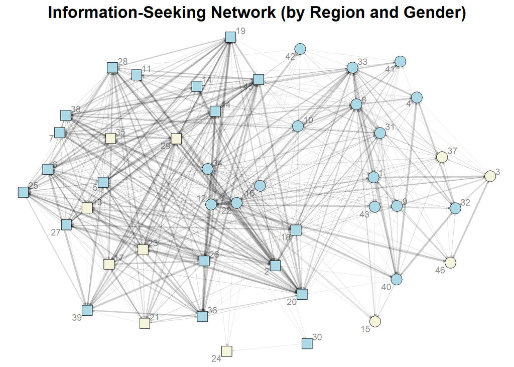

```r
## Visualization of the Information Flow network

ggraph(net_info, layout = "stress") +  # Stress layout for visually balanced node spacing
  geom_edge_link0( # Drawing directed edges with arrowheads
    aes(width = weight), alpha = 0.1, arrow = grid::arrow(angle = 5,
                                       length = unit(0.1, "in"),
                                       type = "closed")) +
  scale_edge_width(range = c(0.1, 1)) +  # Scaling edge width based on weight
  geom_node_point( # Drawing nodes with shape and color by attributes
    fill = ifelse(V(net_info)$gender == 1, "lightblue", "beige"),
    shape = ifelse(V(net_info)$region == 1, 21, 22),
    size = 5) +
  geom_node_text( # Adding node labels with reduced opacity
    aes(label = nodes$ego),
    repel = TRUE, size = 3, alpha = 0.5, color = "grey10") +
ggtitle("Information-Seeking Network (by Region and Gender)") +
  theme_void() +  # For a clean background
  theme(plot.title = element_text(size = 16, face = "bold", hjust = 0.5),
    legend.position = "none")
```

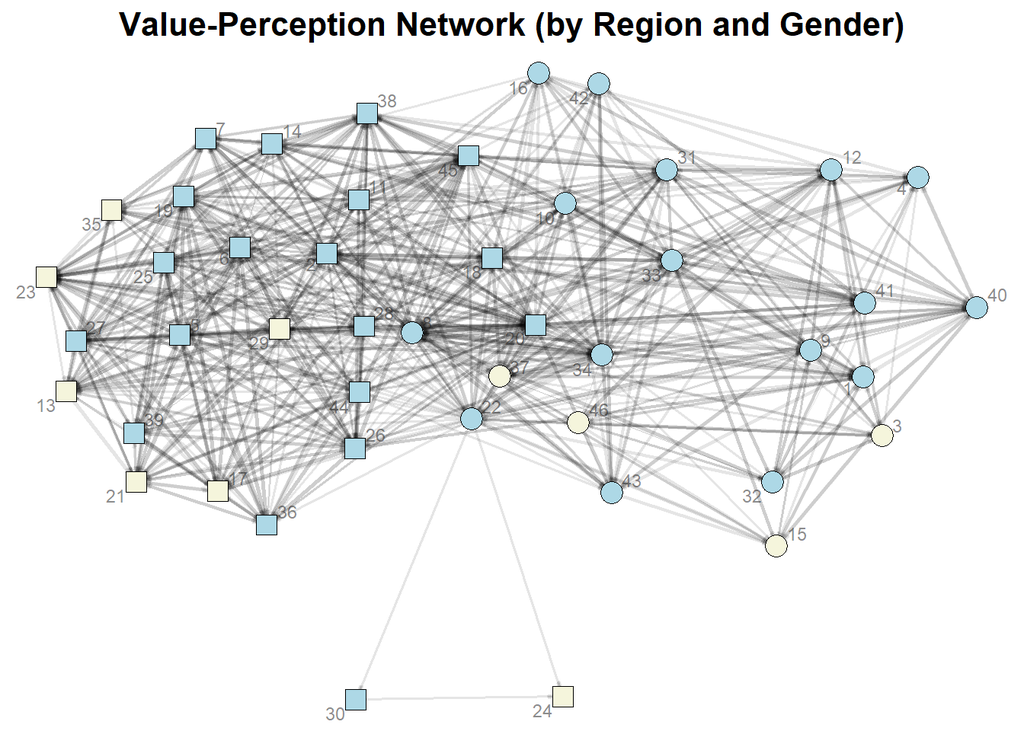

```r
## Visualization of the Value-Perception network

ggraph(net_value, layout = "stress") +
  geom_edge_link0(
    aes(width = weight), alpha = 0.1, arrow = grid::arrow(angle = 5,
                                       length = unit(0.1, "in"),
                                       type = "closed")) +
  scale_edge_width(range = c(0.1, 1)) +
  geom_node_point(
    fill = ifelse(V(net_value)$gender == 1, "lightblue", "beige"),
    shape = ifelse(V(net_value)$region == 1, 21, 22),
    size = 5) +
  geom_node_text(
    aes(label = nodes$ego),
    repel = TRUE, size = 3, alpha = 0.5, color = "grey10") +
ggtitle("Value-Perception Network (by Region and Gender)") +
  theme_void() +
  theme(plot.title = element_text(size = 16, face = "bold", hjust = 0.5),
    legend.position = "none")
```

# Initial Insights

- Both networks are **quite dense**, there seems to be lots of overlapping ties.
- Some nodes (for instance, 30, 24) are more **isolated**.

Since this data is anonymized, I am going to focus on **group-level attributes** and their network characteristics.

# Centrality Measures

## Degree Centrality

Degree Centrality looks at the number of ties for a given node.

Here, since the ties are calculated based on frequency of information/ advice requests, having a high in-degree means more people are coming to the employee for advice/ information. While, having a high out-degree means the employee is asking a lot of people for advice.

```r
## Calculating Degree (Unweighted) for Information Flow
V(net_info)$deg_total <- igraph::degree(net_info, mode = "all")
V(net_info)$deg_in <- igraph::degree(net_info, mode = "in")
V(net_info)$deg_out <- igraph::degree(net_info, mode = "out")

## Calculating Strength (Weighted Degree)
V(net_info)$strength_total <- igraph::strength(net_info, mode = "all", weights = E(net_info)$weight)
V(net_info)$strength_in <- igraph::strength(net_info, mode = "in", weights = E(net_info)$weight)
V(net_info)$strength_out <- igraph::strength(net_info, mode = "out", weights = E(net_info)$weight)
```

```r
## Calculating Degree (Unweighted) for Value Perception
V(net_value)$deg_total <- igraph::degree(net_value, mode = "all")
V(net_value)$deg_in <- igraph::degree(net_value, mode = "in")
V(net_value)$deg_out <- igraph::degree(net_value, mode = "out")

## ⚖Calculating Strength (Weighted Degree)
V(net_value)$strength_total <- igraph::strength(net_value, mode = "all", weights = E(net_value)$weight)
V(net_value)$strength_in <- igraph::strength(net_value, mode = "in", weights = E(net_value)$weight)
V(net_value)$strength_out <- igraph::strength(net_value, mode = "out", weights = E(net_value)$weight)
```

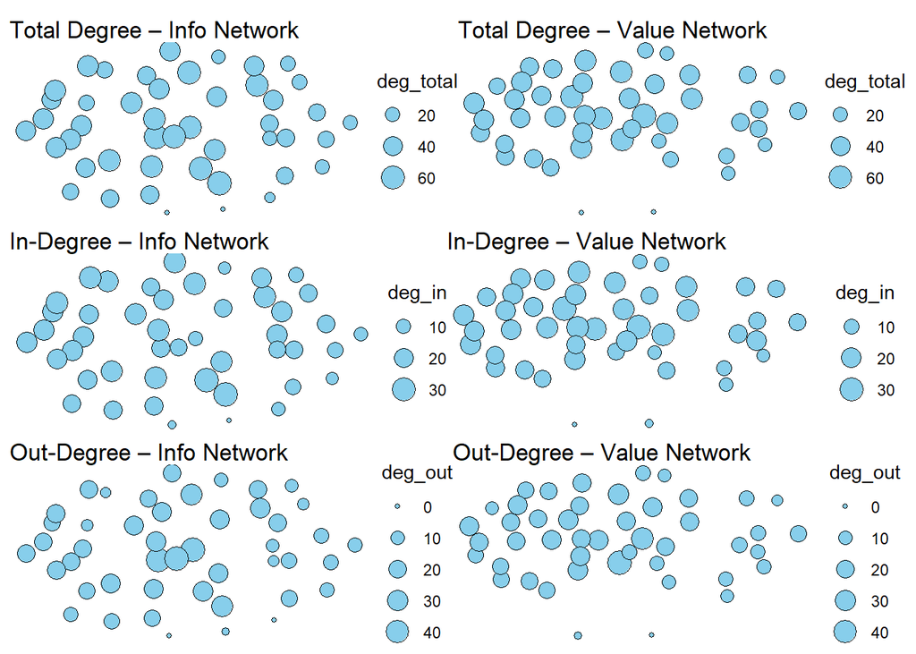

```r
# Visualizing above metrics to get a better idea of the graph
# Degree centrality visualizations

# total degree
p1 <- ggraph(net_info, layout = "stress") +
  geom_node_point(aes(size = deg_total), fill = "skyblue", shape = 21) +
  ggtitle("Total Degree – Info Network") +
  theme_void()

p2 <- ggraph(net_value, layout = "stress") +
  geom_node_point(aes(size = deg_total), fill = "skyblue", shape = 21) +
  ggtitle("Total Degree – Value Network") +
  theme_void()

# in-degree
p3 <- ggraph(net_info, layout = "stress") +
  geom_node_point(aes(size = deg_in), fill = "skyblue", shape = 21) +
  ggtitle("In-Degree – Info Network") +
  theme_void()

p4 <- ggraph(net_value, layout = "stress") +
  geom_node_point(aes(size = deg_in), fill = "skyblue", shape = 21) +
  ggtitle("In-Degree – Value Network") +
  theme_void()

# out degree
p5 <- ggraph(net_info, layout = "stress") +
  geom_node_point(aes(size = deg_out), fill = "skyblue", shape = 21) +
  ggtitle("Out-Degree – Info Network") +
  theme_void()

p6 <- ggraph(net_value, layout = "stress") +
  geom_node_point(aes(size = deg_out), fill = "skyblue", shape = 21) +
  ggtitle("Out-Degree – Value Network") +
  theme_void()

#Display plots
(p1 | p2) / ( p3 | p4) / ( p5 | p6 )
```

Visualizing the graph showed that while there were differences in degree, the **overall structure was densely connected** with no clear standout advisory folks.

Degree centrality captured how many unique ties each employee had, either seeking advice or being consulted, or both. But the distribution was relatively uniform across the network.

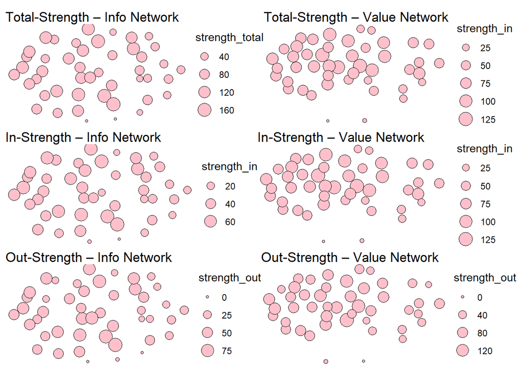

```r
# Strength (weighted degree) visualizations

#total strength
p7 <- ggraph(net_info, layout = "stress") +
  geom_node_point(aes(size = strength_total), fill = "pink", shape = 21) +
  ggtitle("Total-Strength – Info Network") +
  theme_void()

p8 <- ggraph(net_value, layout = "stress") +
  geom_node_point(aes(size = strength_in), fill = "pink", shape = 21) +
  ggtitle("Total-Strength – Value Network") +
  theme_void()

#in-strength
p9 <- ggraph(net_info, layout = "stress") +
  geom_node_point(aes(size = strength_in), fill = "pink", shape = 21) +
  ggtitle("In-Strength – Info Network") +
  theme_void()

p10 <- ggraph(net_value, layout = "stress") +
  geom_node_point(aes(size = strength_in), fill = "pink", shape = 21) +
  ggtitle("In-Strength – Value Network") +
  theme_void()

#out-strength
p11 <- ggraph(net_info, layout = "stress") +
  geom_node_point(aes(size = strength_out), fill = "pink", shape = 21) +
  ggtitle("Out-Strength – Info Network") +
  theme_void()

p12 <- ggraph(net_value, layout = "stress") +
  geom_node_point(aes(size = strength_out), fill = "pink", shape = 21) +
  ggtitle("Out-Strength – Value Network") +
  theme_void()

(p7 | p8) / ( p9 | p10) /( p11 | p12)
```

Visualizing the graph with strength-based centrality showed subtle differences in the **intensity** of ties. Some employees received or gave advice more frequently. However, like degree, strength also appeared broadly distributed. It doesn’t show any differentiated central actors.

```r
# Merging centralities from both networks
V(net_info)$ego <- nodes$ego

comparison_df <- data.frame(
  ego = V(net_info)$ego,
  info_in = V(net_info)$strength_in,
  value_in = V(net_value)$strength_in)

# Correlation
cor.test(comparison_df$info_in, comparison_df$value_in)
```

```
##
##  Pearson's product-moment correlation
##
## data:  comparison_df$info_in and comparison_df$value_in
## t = 11.172, df = 44, p-value = 1.962e-14
## alternative hypothesis: true correlation is not equal to 0
## 95 percent confidence interval:
##  0.7590317 0.9204111
## sample estimates:
##       cor
## 0.8598629
```

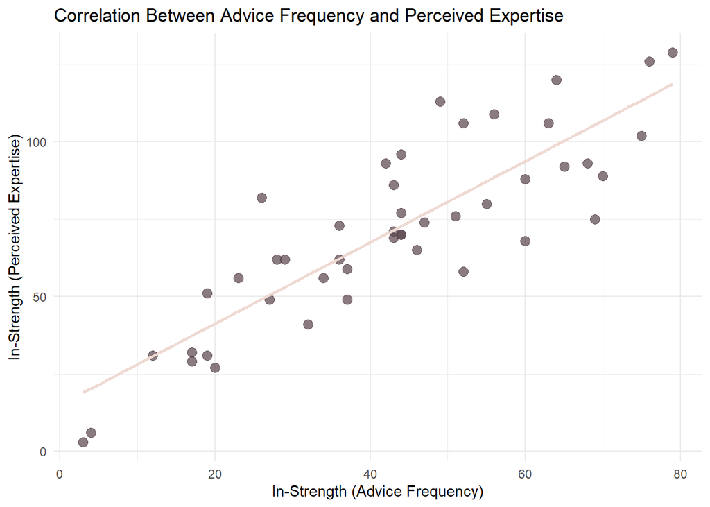

```r
ggplot(comparison_df, aes(x = info_in, y = value_in)) +
  geom_point(color = "#57424a", alpha = 0.7, size = 3) +
  geom_smooth(method = "lm", se = FALSE, color = "#EFD9D3") +
  labs(
    x = "In-Strength (Advice Frequency)",
    y = "In-Strength (Perceived Expertise)",
    title = "Correlation Between Advice Frequency and Perceived Expertise"
  ) +
  theme_minimal()
```

## Correlation Between Advice Frequency and Perceived Expertise

To check whether frequency of advice given also reflects perceived expertise, I compared in-strength centrality across both networks. The result showed a strong positive correlation (r = 0.86), indicating that employees who are frequently asked for advice are generally also perceived as highly knowledgeable.

Based on this finding, I focused the remaining analysis on the **Information-Seeking Network**, as it captures the general essence of both advice flow and perceived value for the purpose of understanding influence, access, and structure within the organization.

### Attribute-Wise Centrality Analysis

Visualizing the graphs did not show strong individual patterns, so I shifted to analyzing centrality by employee attributes such as role, gender, and location. For instance, whether certain roles are more central or if any structural imbalances exist based on demographic characteristics.

```r
V(net_info)$ego <- nodes$ego
V(net_info)$org_level <- nodes$org_level
V(net_info)$gender <- nodes$gender
V(net_info)$region <- nodes$region
V(net_info)$location <- nodes$location


#creating a dataframe to explore attributes and relationship with degree and strength
node_df <- data.frame(
  ego = V(net_info)$ego,
  org_level = V(net_info)$org_level,
  gender = V(net_info)$gender,
  region = V(net_info)$region,
  location = V(net_info)$location,
  deg_total = V(net_info)$deg_total,
  deg_in = V(net_info)$deg_in,
  deg_out = V(net_info)$deg_out,
  strength_total = V(net_info)$strength_total,
  strength_in = V(net_info)$strength_in,
  strength_out = V(net_info)$strength_out
)
```

I am visualizing the degree and strength centrality based on attributes. - **Organizational Level** - **Gender**

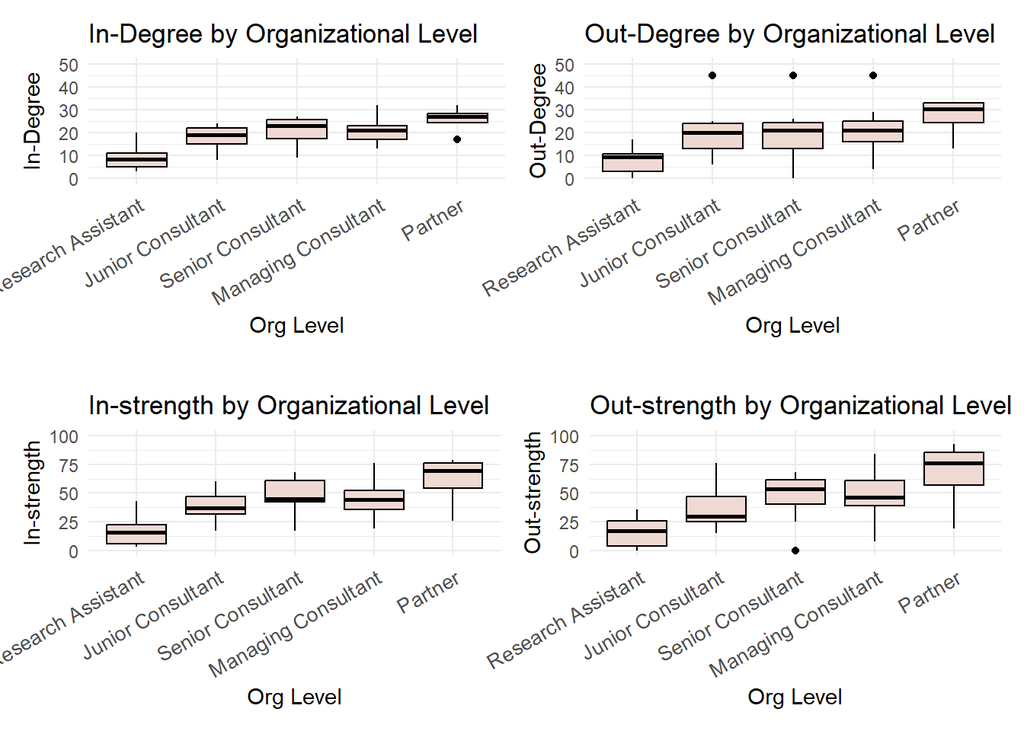

```r
#### Organizational level Degree & Strength Analysis

#Organizational level mapping to make the visualizations more intuitive
org_levels <- c("Research Assistant", "Junior Consultant",
                "Senior Consultant", "Managing Consultant", "Partner")

node_df$org_label <- factor(node_df$org_level,
                            levels = 1:5,
                            labels = org_levels)

## Plotting Organizational-level based in-degree analysis
p13 = ggplot(node_df, aes(x = factor(org_label), y = deg_in)) +
  geom_boxplot(fill = "#EFD9D3", color = "black") +
  coord_cartesian(ylim = c(0, 50)) +
  labs(x = "Org Level", y = "In-Degree", title = "In-Degree by Organizational Level") +
  theme_minimal() +
  theme(axis.text.x = element_text(size = 10, angle = 30, hjust = 1, vjust = 1))

## Plotting Organizational-level based out-degree analysis
p14 = ggplot(node_df, aes(x = factor(org_label), y = deg_out)) +
  geom_boxplot(fill = "#EFD9D3", color = "black") +
  coord_cartesian(ylim = c(0, 50)) +
  labs(x = "Org Level", y = "Out-Degree", title = "Out-Degree by Organizational Level") +
  theme_minimal() +
  theme(axis.text.x = element_text(size = 10, angle = 30, hjust = 1, vjust = 1))

## Plotting Organizational-level based in-strength analysis
p15 = ggplot(node_df, aes(x = factor(org_label), y = strength_in)) +
  geom_boxplot(fill = "#EFD9D3", color = "black") +
  coord_cartesian(ylim = c(0, 100)) +
  labs(x = "Org Level", y = "In-strength", title = "In-strength by Organizational Level") +
  theme_minimal() +
  theme(axis.text.x = element_text(size = 10, angle = 30, hjust = 1, vjust = 1))

## Plotting Organizational-level based out-strength analysis
p16 = ggplot(node_df, aes(x = factor(org_label), y = strength_out)) +
  geom_boxplot(fill = "#EFD9D3", color = "black") +
  coord_cartesian(ylim = c(0, 100)) +
  labs(x = "Org Level", y = "Out-strength", title = "Out-strength by Organizational Level") +
  theme_minimal() +
  theme(axis.text.x = element_text(size = 10, angle = 30, hjust = 1, vjust = 1))

options(repr.plot.width = 16, repr.plot.height = 10)

(p13 | p14) / plot_spacer() / (p15 | p16) + plot_layout(heights = c(1, 0.1, 1))
```

These results reinforce a **hierarchical but participatory structure**, where centrality generally increases with seniority, but variation within roles highlights opportunities for coaching or more structured mentoring.

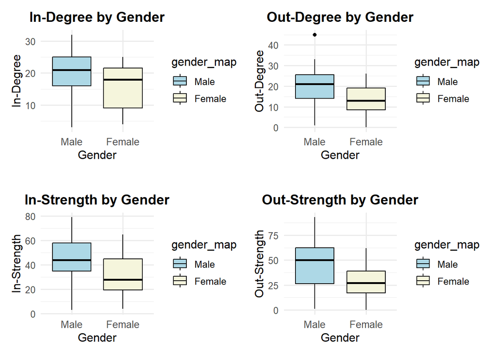

```r
#### Gender-based Degree & Strength Analysis

#Gender mapping to make the visualizations more intuitive
gender_map <- c("Male", "Female")
node_df$gender_map <- factor(node_df$gender,
                            levels = 1:2,
                            labels = gender_map)

## Plotting Gender-based in-degree analysis
p17 <- ggplot(node_df, aes(x = gender_map, y = deg_in, fill = gender_map)) +
  geom_boxplot(color = "black") +
  #coord_cartesian(ylim = c(0, 50)) +
  scale_fill_manual(values = c("Male" = "lightblue", "Female" = "beige")) +
  labs(x = "Gender", y = "In-Degree", title = "In-Degree by Gender") +
  theme_minimal(base_size = 12) +
  theme(
    axis.text.x = element_text(size = 10),
    plot.title = element_text(size = 14, face = "bold", hjust = 0.5)
  )

## Plotting Gender-based out-degree analysis
p18 <- ggplot(node_df, aes(x = gender_map, y = deg_out, fill = gender_map)) +
  geom_boxplot(color = "black") +
  #coord_cartesian(ylim = c(0, 50)) +
  scale_fill_manual(values = c("Male" = "lightblue", "Female" = "beige")) +
  labs(x = "Gender", y = "Out-Degree", title = "Out-Degree by Gender") +
  theme_minimal(base_size = 12) +
  theme(
    axis.text.x = element_text(size = 10),
    plot.title = element_text(size = 14, face = "bold", hjust = 0.5)
  )

## Plotting Gender-based in-strength analysis
p19 <- ggplot(node_df, aes(x = gender_map, y = strength_in, fill = gender_map)) +
  geom_boxplot(color = "black") +
  #coord_cartesian(ylim = c(0, 100)) +
  scale_fill_manual(values = c("Male" = "lightblue", "Female" = "beige")) +
  labs(x = "Gender", y = "In-Strength", title = "In-Strength by Gender") +
  theme_minimal(base_size = 12) +
  theme(
    axis.text.x = element_text(size = 10),
    plot.title = element_text(size = 14, face = "bold", hjust = 0.5)
  )

## Plotting Gender-based out-strength analysis
p20 <- ggplot(node_df, aes(x = gender_map, y = strength_out, fill = gender_map)) +
  geom_boxplot(color = "black") +
  #coord_cartesian(ylim = c(0, 100)) +
  scale_fill_manual(values = c("Male" = "lightblue", "Female" = "beige")) +
  labs(x = "Gender", y = "Out-Strength", title = "Out-Strength by Gender") +
  theme_minimal(base_size = 12) +
  theme(
    axis.text.x = element_text(size = 10),
    plot.title = element_text(size = 14, face = "bold", hjust = 0.5)
  )

(p17 | p18) / plot_spacer() / (p19 | p20) + plot_layout(heights = c(1, 0.1, 1))
```

The boxplots reveal consistent gender differences across both degree and strength centrality measures.

- **Male employees** have higher average in-degree and out-degree, suggesting they are more frequently sought out and more proactive in seeking advice. Their higher in- and out-strength further indicates stronger or more frequent ties across the network.
- **Female employees**, despite having lower average centrality, show **greater variation in in-degree and in-strength**. This suggests that while some are less embedded, others are more central and approachable, possibly due to individual trust, visibility, or role expectations. This could also indicate that employees are more likely to seek advice from certain female colleagues.

These findings raise important considerations around **network inclusivity** and **informal influence**. Some female employees appear to serve as key advice hubs, despite overall lower average.

## Closeness Centrality

Closeness measures how close a node is to all other nodes in the network. Here, since we’re dealing with directed advice netwrok, in- closeness looks at how easily a person can be reached by others for providing/ offering advice, and out-closeness indicates how efficiently a person can reach out to others for advice.

```r
## Calculating closeness centrality (weights ignored) and assigning to network object
V(net_info)$closeness_in <- igraph::closeness(net_info, mode = "in")
V(net_info)$closeness_out <- igraph::closeness(net_info, mode = "out")

## Adding measures to the node_df dataframe
node_df$closeness_in <- V(net_info)$closeness_in
node_df$closeness_out <- V(net_info)$closeness_out
```

Closeness centrality was computed using the **unweighted network**, where each tie is treated equally, regardless of frequency. This approach focuses purely on the structural position of each employee in terms of reachability and accessibility in the advice network.

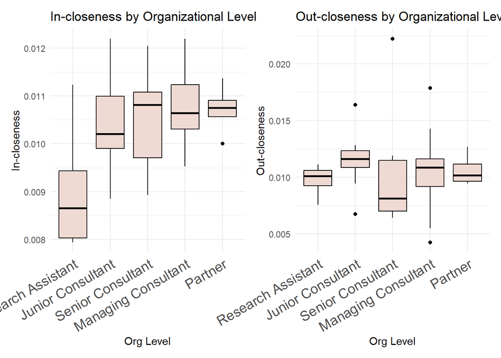

```r
#### Organizational level Closeness Analysis

## Plotting Organizational-level-based in-closeness analysis
p23 = ggplot(node_df, aes(x = factor(org_label), y = closeness_in)) +
  geom_boxplot(fill = "#EFD9D3", color = "black") +
  labs(x = "Org Level", y = "In-closeness", title = "In-closeness by Organizational Level") +
  theme_minimal() +
  theme(axis.text.x = element_text(size = 14, angle = 30, hjust = 1, vjust = 1))

## Plotting Organizational-level-based out-closeness analysis
p24 = ggplot(node_df %>% filter(closeness_out < 0.05),
       aes(x = factor(org_label), y = closeness_out)) +
  geom_boxplot(fill = "#EFD9D3", color = "black") +
  labs(x = "Org Level", y = "Out-closeness", title = "Out-closeness by Organizational Level") +
  theme_minimal() +
  theme(axis.text.x = element_text(size = 14, angle = 30, hjust = 1, vjust = 1))

options(repr.plot.width = 20, repr.plot.height = 8)

p23 | p24
```

- **In-Closeness** appears to reflect the organizational hierarchy, with more senior roles (e.g., Consultants and Managers) being more reachable. Interestingly, **Partners** show slightly lower in-closeness than expected, which may reflect their advisory or less day-to-day operational role.
- **Out-Closeness** scores are similar across organizational levels, but **Senior Consultants** show a wider range. This suggests variability in how efficiently individuals in that role reach others. possibly influenced by client teams or role flexibility. But in general, employees are able to reach other employees if required.

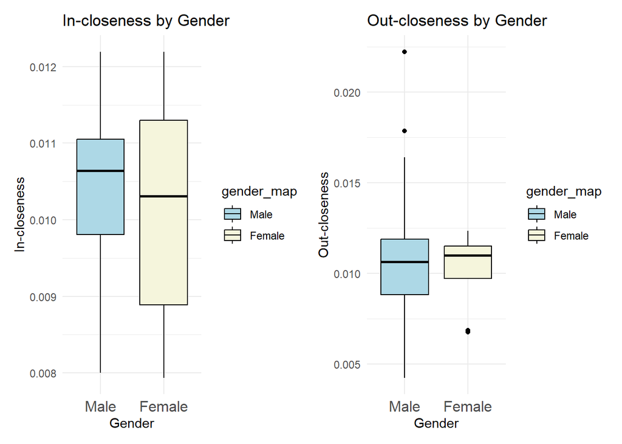

```r
#### Gender based Closeness Analysis

## Plotting Gender-based in-closeness analysis
p25 = ggplot(node_df, aes(x = factor(gender_map), y = closeness_in, fill = gender_map)) +
  geom_boxplot(color = "black") +
   scale_fill_manual(values = c("Male" = "lightblue", "Female" = "beige")) +
  labs(x = "Gender", y = "In-closeness", title = "In-closeness by Gender") +
  theme_minimal() +
  theme(axis.text.x = element_text(size = 12))

## Plotting Gender-based out-closeness analysis
p26 = ggplot(node_df %>% filter(closeness_out < 0.05),
       aes(x = factor(gender_map), y = closeness_out, fill = gender_map)) +
  geom_boxplot(color = "black") +
   scale_fill_manual(values = c("Male" = "lightblue", "Female" = "beige")) +
  labs(x = "Gender", y = "Out-closeness", title = "Out-closeness by Gender") +
  theme_minimal() +
  theme(axis.text.x = element_text(size = 12))

options(repr.plot.width = 16, repr.plot.height = 6)

p25 | p26
```

- **In-Closeness**, however, shows **greater variation among female employees**, suggesting differences in approachability or visibility within the network. Some women are highly reachable, while others may be more peripheral.
- **Out-Closeness** is consistent across genders, indicating comparable ability to reach others for advice.

## Betweenness Centrality

Betweenness centrality measures how often a person lies on the shortest paths between others.

In this network, betweenness centrality indicates how often a person acts as an information bridge connecting others seeking advice from each other.

```r
## Calculating betweenness centrality and assigning to network object
V(net_info)$betweenness <- igraph::betweenness(net_info, directed = TRUE)
node_df$betweenness <- V(net_info)$betweenness
```

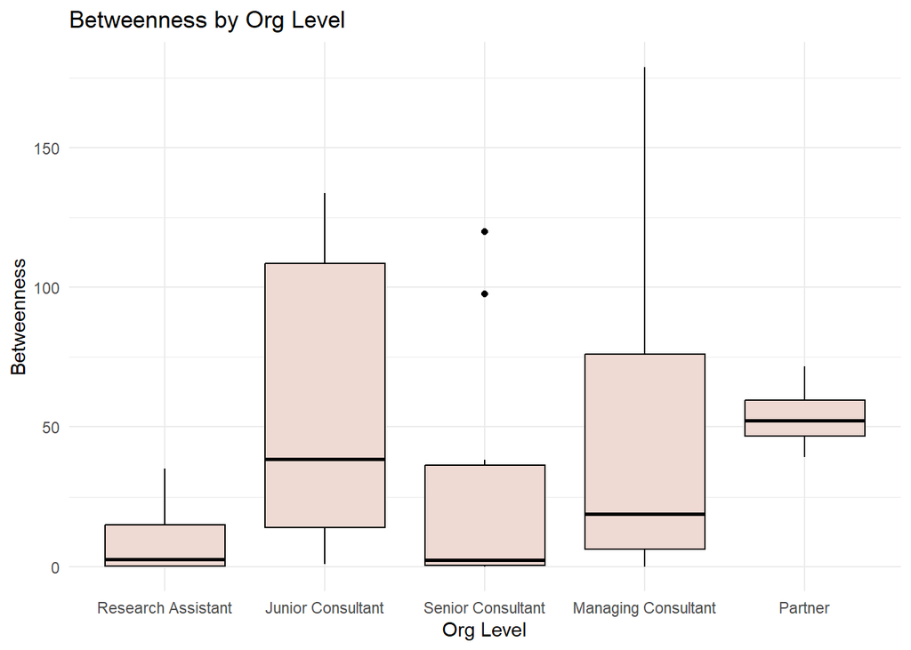

```r
#### Betweenness Visualizations

#### Organizational level Betweenness Analysis

## plotting betweenness across organizational levels
p27 = ggplot(node_df, aes(x = org_label, y = betweenness)) +
  geom_boxplot(fill = "#EFD9D3", color = "black") +
  labs(x = "Org Level", y = "Betweenness", title = "Betweenness by Org Level") +
  theme_minimal()

p27
```

```r
options(repr.plot.width = 8, repr.plot.height = 4)
```

Betweenness centrality varied across roles.

**Consultants** showed the **widest range**, while **partners** consistently acted as **stable bridges**, suggesting that consultants are unevenly embedded in the network (some act as key brokers, others not) whereas partners maintain a steady position of influence across subgroups.

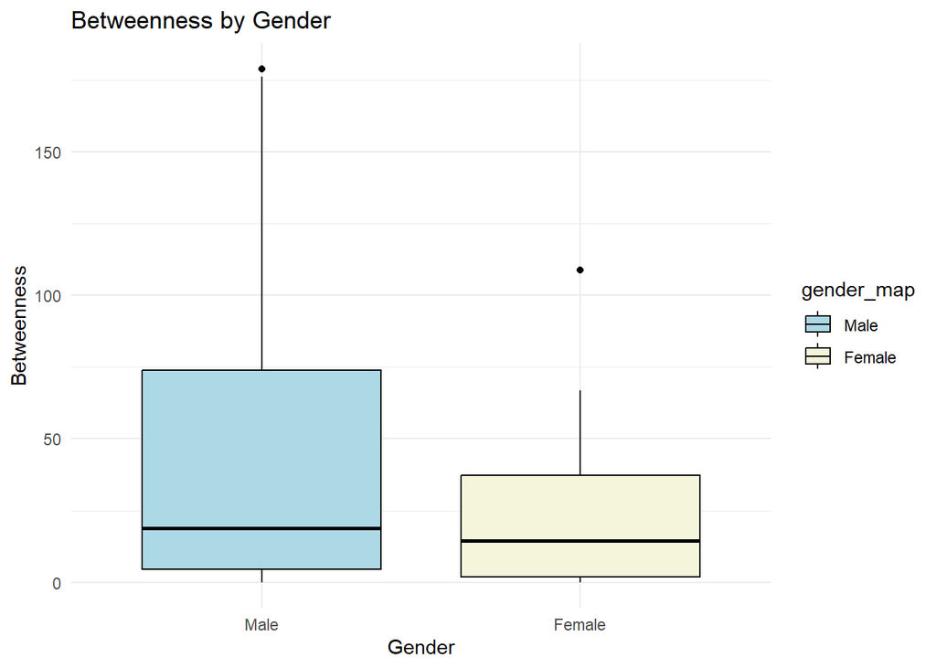

```r
#### Gender based Betweenness Analysis

## plotting betweenness across Genders
p28 = ggplot(node_df, aes(x = factor(gender_map), y = betweenness, fill = gender_map)) +
  geom_boxplot(color = "black") +
   scale_fill_manual(values = c("Male" = "lightblue", "Female" = "beige")) +
  labs(x = "Gender", y = "Betweenness", title = "Betweenness by Gender") +
  theme_minimal()

options(repr.plot.width = 6, repr.plot.height = 6)

p28
```

**Male employees had higher and more varied betweenness** than females, though outliers were observed in both groups, suggesting that males more frequently act as intermediaries in advice flow, in comparison with their female counterparts.

# Centralization measures

Centralization calculates network-level scores for each centrality measure; these scores help assess whether the advice network is hierarchical or evenly distributed in terms of access, influence, and brokerage

```r
# Degree Centralization
cent_deg <- centr_degree(net_info, mode = "all")$centralization
# Closeness Centralization
cent_clo <- centr_clo(net_info, mode = "all")$centralization
# Betweenness Centralization
cent_bet <- centr_betw(net_info)$centralization
# Eigenvector Centralization
cent_evc <- centr_eigen(net_info)$centralization

round(cent_deg, 2)
```

```
## [1] 0.31
```

```r
round(cent_clo, 2)
```

```
## [1] 0.63
```

```r
round(cent_bet, 2)
```

```
## [1] 0.06
```

```r
round(cent_evc, 2)
```

```
## [1] 0.43
```

- **Degree centralization (0.31)** suggests moderate variation in how many people each employee seeks or receives advice from.
- **Closeness centralization (0.63)** shows advice access is slightly concentrated among a few highly reachable employees.
- **Betweenness centralization (0.06)** confirms the network does not rely on a single person for advice- multiple advice pathways exist.
- **Eigenvector centralization (0.43)** indicates influence is uneven, with certain individuals connected to other central players.

# Structure

## Density, Dyad and Triad Census

```r
#Edge density
edge_density(net_info)
```

```
## [1] 0.4236715
```

```r
#Dyads
dyad_census(net_info)
```

```
## $mut
## [1] 327
##
## $asym
## [1] 223
##
## $null
## [1] 485
```

```r
#Triads
net_sna <- asNetwork(net_info)
sna::triad.census(net_sna)
```

```
##       003  012  102 021D 021U 021C 111D 111U 030T 030C  201 120D 120U 120C  210
## [1,] 2026 1811 3812  880  123  106  435 1418  253    2 1054  512  393  135 1085
##       300
## [1,] 1135
```

```r
colnames(sna::triad.census(net_sna))[which.max(sna::triad.census(net_sna))] #which triad is the most common?
```

```
## [1] "102"
```

```r
colnames(sna::triad.census(net_sna))[which.min(sna::triad.census(net_sna))] #which triad is the least common?
```

```
## [1] "030C"
```

**Density** * **Moderately dense** network: nearly 42% of possible advice ties are present.

**Dyads** * **Mutual advice ties (327) are common**, which shows reciprocal information sharing. * **Nulls still dominate (485)**, suggesting not everyone is connected.

**Triads** * Most common triad is 102: **one mutual tie and an isolate** * High number of 003 and 012: many dyads are disconnected or have **only one direction of advice** * Triads with **full mutual ties** (300, 210) are frequent, indicating small tightly knit groups of mutual advisors * **Very few cyclical triads** (030C): advice does not typically circulate in loops

## Transitivity

Transitivity refers to the degree to which a relationship between two nodes in a network is also present between the nodes they are connected to.

I also used a CUG (Conditional Uniform Graph) test to determine if the network’s structure is statistically different from a random network with the same characteristics.

```r
# Transitivity
summary(igraph::transitivity(net_info, type = "global"))
```

```
##    Min. 1st Qu.  Median    Mean 3rd Qu.    Max.
##  0.7283  0.7283  0.7283  0.7283  0.7283  0.7283
```

```r
summary(igraph::transitivity(net_info, type = "local", isolates = "zero"))
```

```
##    Min. 1st Qu.  Median    Mean 3rd Qu.    Max.
##  0.1832  0.2592  0.2909  0.3573  0.3508  1.0000
```

```r
cug.test(net_sna, gtrans, cmode = "edges")
```

```
##
## Univariate Conditional Uniform Graph Test
##
## Conditioning Method: edges
## Graph Type: digraph
## Diagonal Used: FALSE
## Replications: 1000
##
## Observed Value: 0.6931773
## Pr(X>=Obs): 0
## Pr(X<=Obs): 1
```

The results show that the **network is more clustered than expected by chance**.

The higher-than-expected clustering suggests that employees form informal circles or cliques for advice. While this can foster trust and collaboration, it may also limit access to diverse perspectives if these clusters become too insular.

## Assortativity

Assortativity measures the tendency of employees to connect with others who share similar attributes (e.g., gender, role, or region), revealing patterns of homophily or diversity in advice-seeking behavior.

```r
# Assortativity
## Based on Gender
assort_gender_d <- igraph::assortativity_nominal(net_info, V(net_info)$gender, directed = TRUE)
assort_gender_u <- assortativity_nominal(net_info, V(net_info)$gender, directed = FALSE)

## Based on Organizational Level
assort_org_d <- assortativity_nominal(net_info, V(net_info)$org_level, directed = TRUE)
assort_org_u <- assortativity_nominal(net_info, V(net_info)$org_level, directed = FALSE)

round(assort_gender_d, 3)
```

```
## [1] -0.008
```

```r
round(assort_gender_u, 3)
```

```
## [1] -0.01
```

```r
round(assort_org_d, 3)
```

```
## [1] -0.019
```

```r
round(assort_org_u, 3)
```

```
## [1] -0.019
```

The values suggest there is **no homophily based on gender and organizational level**.

This suggests employees don’t necessarily only collaborate or seek advice only with employees with similar attributes (here, gender and organiztional level), highlighting existing collaboratios between genders and various organizational levels.

# Clustering and Communities

In this section, I explored the community structure within the advice-seeking network to see whether the network naturally splits into smaller, densely connected groups, or if it’s more integrated.

From a business perspective, this insight can help identify: - **Teams or clusters** that collaborate more closely - Areas where **cross-functional interaction** could be encouraged - Opportunities to **strengthen information flow** across silos (if silos exist)

I chose spinglass because it works well with weighted, undirected networks and is effective for small networks.

```r
#Spinglass with varied resolution parameters
set.seed(1)
csg_1 <- cluster_spinglass(net_info, gamma = 0.01)
length(csg_1)
```

```
## [1] 1
```

```r
round(modularity(csg_1), 3)
```

```
## [1] 0.28
```

```r
csg_2 <- cluster_spinglass(net_info, gamma = 0.05)
length(csg_2)
```

```
## [1] 1
```

```r
round(modularity(csg_2), 3)
```

```
## [1] 0.277
```

```r
csg_3 <- cluster_spinglass(net_info, gamma = 0.1)
length(csg_3)
```

```
## [1] 3
```

```r
round(modularity(csg_3), 3)
```

```
## [1] 0.269
```

```r
csg_4 <- cluster_spinglass(net_info, gamma = 0.5)
length(csg_4)
```

```
## [1] 2
```

```r
round(modularity(csg_4), 3)
```

```
## [1] 0.178
```

```r
csg_5 <- cluster_spinglass(net_info, gamma = 1)
length(csg_5)
```

```
## [1] 3
```

```r
round(modularity(csg_5), 3)
```

```
## [1] 0.118
```

```r
csg_6 <- cluster_spinglass(net_info, gamma = 2)
length(csg_6)
```

```
## [1] 12
```

```r
round(modularity(csg_6), 3)
```

```
## [1] 0.032
```

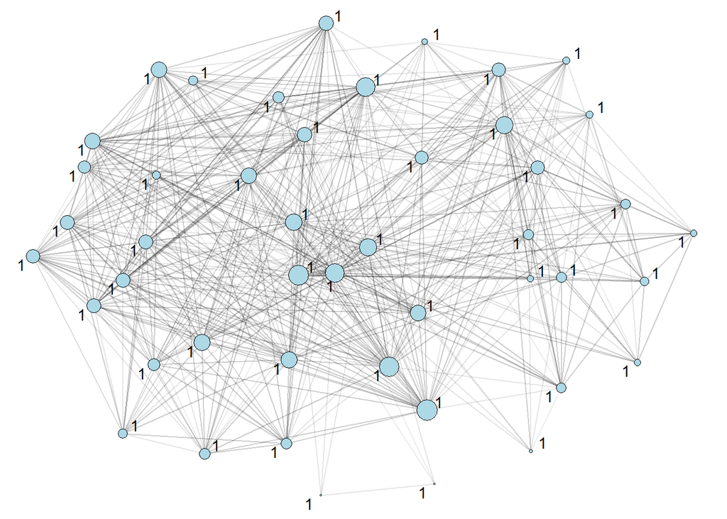

```r
colors <- colorpanel(length(csg_1), low = "lightblue", high = "pink")
csg_1_plot <- ggraph(net_info, layout = "stress") +
  geom_edge_link0(color = "black", alpha = .1) +
  geom_node_point(aes(fill = as.factor(membership(csg_1))),
                  size = 0.1*(igraph::degree(net_info, mode = "all")),
                  color = "black", shape = 21) +
  scale_fill_manual(values = c(colors)) +
  theme_void() +
  geom_node_text(aes(label = as.factor(membership(csg_1))), repel = T) +
  theme(legend.position = "none")

options(repr.plot.width = 8, repr.plot.height = 6)
csg_1_plot
```

Community detection using the Spinglass algorithm showed that the network operates as a single, tightly connected cluster.

The **highest modularity (0.280) was achieved at a low resolution (gamma = 0.01)**, indicating limited subgroup structure.

This supports the idea of a collaborative and open information-sharing culture, where **advice flows freely across boundaries** without forming isolated silos.

Even though there is local clustering (triadic closure), the network forms only one clear community. This indicates that advice ties are broadly distributed without distinct group boundaries.

# Contagion Simulation (Threshold Diffusion)

Contagion analysis helps simulate how ideas, behaviors, or innovations spread through a network over time. In an organizational setting, this could represent the spread of a new policy, training program, or best practice.

Key business questions this addresses include: - *If a few employees adopt a new idea, how quickly does it reach others?* - *Are there bottlenecks or isolated subgroups that slow down diffusion?* - *Is the network structure enabling or hindering the spread of innovation?*

I used a **threshold diffusion model**, where individuals adopt the behavior if a certain proportion of their neighbors have already adopted it.

```r
#Performing Contagion Simulation

# Creating an undirected version of the network (diffusion is mutual)
un_net <- graph_from_data_frame(edges_info, directed = F, vertices = nodes)

# Converting to adjacency matrix, required for rdiffnet
net_sna_adj <- as_adjacency_matrix(un_net)

# Defining number of nodes (used internally by rdiffnet)
n_nodes <- nrow(net_sna_adj)

# Step 4: Running the threshold diffusion model
set.seed(1)

diffnet_il <- rdiffnet(
  t = 5, # Simulate over 5 time periods
  seed.graph = net_sna_adj, # Base network for simulation
  seed.nodes = "random", # Randomly select initial adopters
  seed.p.adopt = 0.3, # 50% of the seed nodes start as adopters
  rewire = F, # No changes to network structure mid-simulation
  threshold.dist = function(i) 0.25,  # Adoption threshold: adopt if 25% of neighbors do
  exposure.args = list(normalized = T)  # Normalize exposure for comparability
)

summary(diffnet_il)
```

```
## Diffusion network summary statistics
##  Name     :  A diffusion network
##  Behavior : Random contagion
## -----------------------------------------------------------------------------
##  Period   Adopters   Cum Adopt. (%)   Hazard Rate   Density   Moran's I (sd)
## -------- ---------- ---------------- ------------- --------- ----------------
##        1         13        13 (0.28)             -      0.53 -0.04 (0.01)
##        2         26        39 (0.85)          0.79      0.53 -0.01 (0.01) *
##        3          7        46 (1.00)          1.00      0.53               -
##        4          0        46 (1.00)          0.00      0.53               -
##        5          0        46 (1.00)          0.00      0.53               -
## -----------------------------------------------------------------------------
##  Left censoring  : 0.28 (13)
##  Right centoring : 0.00 (0)
##  # of nodes      : 46
##
##  Moran's I was computed on contemporaneous autocorrelation using 1/geodesic
##  values. Significane levels  *** <= .01, ** <= .05, * <= .1.
```

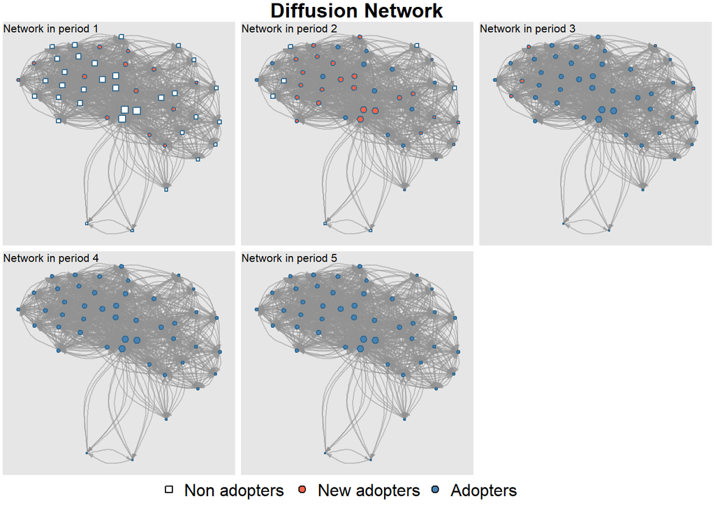

```r
options(repr.plot.width = 12, repr.plot.height = 8)
plot_diffnet(diffnet_il, slices = c(1, 2, 3, 4, 5))
```

Starting with 30% of employees as early adopters, the behavior spread quickly. 85% had adopted it by the second round, and everyone adopted by the third.

The high hazard rate shows that people were likely to adopt when they saw others doing it. Moran’s I was close to zero, which means the spread wasn’t limited to specific groups, it happened across the network.

This shows that the **network is well-connected and ideas can spread easily**.

# Conclusion and Findings

The advice network in this consulting firm is well-connected, with advice flowing through multiple paths rather than being dependent on a few individuals. While some employees are clearly more central, access to advice appears relatively balanced across the organization.

The lack of tightly separated groups suggests that employees collaborate across teams, levels, and locations, which is a strong sign of openness and knowledge sharing.

However, the analysis also revealed a few areas for improvement:

**Support key influencers** A few employees play a major role in advice flow. These individuals can be formally recognized or mentored into leadership roles to strengthen internal knowledge transfer.

**Encourage more cross-level interaction** Some roles tend to seek less advice from others, for instance, Research Assistants. Initiatives like mentoring, cross-functional projects, or rotational programs can break these patterns.

**Watch for extremes** A few employees are giving or seeking advice at much higher levels than others. This may be due to specific job roles or team dynamics. It might be worth exploring to avoid overload or dependency.

**Capitalize on strong diffusion** The contagion analysis shows that information spreads quickly across the network. This means the company is well-positioned to roll out new ideas or practices efficiently. This is a strategic advantage for internal communication and change management.

Overall, this was an interesting project to work on. The findings from this network analysis, if replicated in real organizations, can offer valuable understanding of how information flows or how a network is sttructured, whether in communication networks, people analytics, or even supply chains (e.g., flow of goods or decisions).

From a **People Analytics** perspective, identifying key individuals and understanding structural patterns can support smarter organizational design. For instance, recognizing central employees or bottlenecks can help optimize communication, mentorship, and collaboration. Network analysis like this holds great potential in **designing more efficient, inclusive, and resilient teams**.

## Key Tools & Concepts Applied

- igraph, ggraph, patchwork, netdiffuseR
- Centrality, Clustering, Assortativity, Contagion Simulation
- Group-level attribute analysis and business impact